# STA211 : Méta-algorithmes

Vincent Audigier

04 mai, 2026

# 1 Introduction

Différentes méthodes supervisées ont été présentées dans cette partie. Il est possible d’en améliorer les performances en utilisant des méthodes d’agrégation qui consistent à combiner plusieurs prédictions fournies par différents modèles. Ce type d’approche a déjà été abordé au travers des forêts aléatoires dans la mesure où une forêt peut être vue comme la combinaison des règles de prédictions fournies par plusieurs arbres. Nous présentons ici deux procédures d’agrégation très classiques : le bagging et le boosting.

# 2 Bagging

Nous présentons d’abord le bagging dans le cadre d’un problème de régression, puis développons ensuite ses spécificités dans le cadre de la classification.

## 2.1 Régression

Le Bagging est aussi appelé *agrégation bootstrap*. Il s’agit d’une procédure qui permet de réduire la variance d’une méthode supervisée. Le fondement de cette méthode repose sur le résultat suivant : si on se donne un $n$-échantillon $(T_1,\ldots,T_n)$, tel que $\text{Var}\left[T_i\right]=\sigma^2$ pour tout $1\leq i\leq n$, alors $\text{Var}\left[\frac{1}{n}\sum_{i=1}^nT_i\right]=\sigma^2/n$. Autrement dit, si on dispose de $n$ réalisations indépendantes d’une variable aléatoire $T$, alors la moyenne de ces $n$ valeurs est $n$ fois moins variable que $T$. Notons que l’espérance de cette moyenne ne sera quant à elle pas modifiée. En appliquant ce résultat à différents prédicteurs on espère obtenir un prédicteur ``moyen’’ avec moins de variance que chacun des prédicteurs pris isolément (mais avec un biais similaire). Ceci est vrai à condition de disposer de plusieurs prédicteurs indépendants les uns des autres.

Le principe du Bagging est alors le suivant : tout d’abord, on constitue $B$ échantillons bootstrap à partir des données. Pour cela, on peut soit faire du ré-échantillonnage avec remise des $n$ individus de façon à constituer $B$ échantillons de taille $n$, soit constituer des échantillons de taille inférieure (via des tirages avec ou sans remise). Ces $B$ échantillons sont constitués indépendamment les uns des autres. Par la suite, on construit un modèle pour chaque échantillon bootstrap (par exemple un arbre non élagué). On agrège enfin les modèles en moyennant les prédictions de chacun. Notons que pour certains modèles, faire la moyenne des prédictions revient à faire la moyenne des paramètres de ces modèles, puis à retenir les prédictions correspondantes, mais ce n’est pas toujours le cas, et naturellement pour un modèle non-paramétrique, tel qu’un arbre, ceci n’a pas même de sens.

Le tirage d’échantillons indépendants ne suffit pas à garantir l’indépendance entre les $B$ prédictions obtenues dans la mesure où toutes restent construites à partir du même jeu de données. Ainsi, on privilégie généralement des prédicteurs instables (i.e. dont la prédiction varie beaucoup en fonction de l’échantillon d’apprentissage considéré), tels que les arbres, de façon à limiter le lien entre les $B$ différentes prédictions. Par ailleurs, dans la mesure où le bagging a pour objectif de réduire la variabilité de la prédiction, il ne sera généralement pas utile de l’appliquer sur des modèles stables. Pour autant, il n’est pas nécessairement judicieux de considérer des prédicteurs très fortement variables car le prédicteur *baggé* (i.e. agrégé par bagging) pourrait avoir une variance importante, bien que celle-ci ait été diminuée par rapport au prédicteur de base. De ce point de vue, considérer des prédicteurs de base non biaisés (et donc avec une variance importante) n’est pas forcément un bon choix.

Le fait de n’utiliser qu’une partie de l’échantillon d’apprentissage via le bootstrap permet d’utiliser les individus non sélectionnés en tant qu’échantillon test et donc d’estimer une erreur de prédiction appelée erreur *out-of-bag* (littéralement, *en dehors du bootstrap*) ou simplement OOB. Plus précisément, cette erreur se calcule de la façon suivante : on fixe une observation $(x_i,y_i)$ de l’échantillon d’apprentissage. On considère ensuite parmi les $B$ prédicteurs construits, le sous ensemble des prédicteurs $\hat{f}_b$ construits sans cette observation, i.e. pour lesquels cette observation est ``Out-Of-Bag’’. On agrège alors (en les moyennant) les prédictions correspondantes pour fournir une unique prédiction $\hat{y}_i$ de $Y_i$. On répète l’opération pour toutes les observations et on calcule ensuite l’erreur quadratique moyenne, correspondant à l’erreur OOB :

$$\left(\frac{1}{n}\sum_{i=1}^n\left(\hat{y}_i-y_i\right)^2\right)$$

Ainsi, la procédure de Bagging fournit directement une estimation de la perte.

Le bénéfice à utiliser le bagging tient d’une part au fait de moyenner les règles de prédiction : on gagnera généralement à considérer un très grand nombre de prédicteurs, car plus $B$ est grand, plus la variance des valeurs prédites sera petite. D’autre part, le bagging peut être avantageux en présence de valeurs aberrantes. Ceci tient au fait que certaines valeurs aberrantes présentes dans les données ne se retrouvent que dans certains échantillons bootstrap et que la moyenne des prédictions bootstrap fait perdre leur influence à ces valeurs aberrantes.

## 2.2 Classification

Dans un cadre de classification, le bagging reste construit de façon très similaire : on ré-échantillonne les données $B$ fois, on se donne un classifieur pour chaque échantillon puis on agrège les règles de classification ensemble. Quelques spécifiés aux variables réponses qualitatives doivent néanmoins être mentionnées.

En particulier, il est fréquent de s’intéresser davantage à la probabilité d’appartenance à une classe, qu’à la classe prédite elle-même. En effet, on peut prédire qu’un client sera un bon payeur, mais savoir que la probabilité qu’il le soit vaille 0.99 ou 0.51 est également riche d’information. Pour obtenir cette probabilité à partir du bagging, il serait tentant de vouloir calculer pour chaque individu les fréquences relatives des classes prédites par les $B$ prédicteurs. Ceci n’est en général pas pertinent. Par exemple, supposons deux prédicteurs tels que chacun donne une probabilité de 0.8 pour que la sortie associée à une entrée $x_0$ vaille ‘1’. Dans ce cas, chacun prédira ‘1’ pour la sortie, et donc la probabilité d’appartenance à la classe ‘1’ serait estimée par 1, ce qui est très approximatif. Il vaut mieux faire la moyenne des probabilités données par les $B$ prédicteurs. Par exemple, dans le cas des arbres, on considérera la proportion de chaque classe au sein de la feuille à laquelle appartient l’entrée $x_0$.

Par ailleurs, même si l’objectif est purement prédictif et que l’on ne s’intéresse pas à la probabilité d’affecter un individu à une classe plutôt qu’une autre, il pourra être également préférable d’agréger les probabilités prédites pour chaque prédicteur, puis de retenir la classe la plus probable, plutôt que de considérer la classe majoritaire pour les différents prédicteurs. Ceci permet d’obtenir des prédicteurs moins variables, en particulier quand le nombre de prédicteurs est petit (Hastie, Tibshirani, and Friedman (2009)).

Enfin, précisons qu’il est également possible de calculer une erreur OOB dans un cadre de classification. Pour cela, on procède de façon similaire au cadre de la régression en choisissant un critère d’erreur adapté à la nature qualitative de la réponse, en l’occurrence l’erreur de mauvais classement.

## 2.3 Importance des variables

Une fonctionnalité majeure des méthodes de bagging est qu’elles offrent un moyen de hiérarchiser les variables explicatives en fonction de leur importance dans le modèle. Ceci permet notamment de retrouver une certaine **interprétabilité** du modèle que l’on perd à travers la stratégie d’agrégation.

L’importance d’une variable $X^j$ se détermine en calculant, pour chaque prédicteur, la différence entre l’erreur OOB et cette même erreur si les valeurs de $X^j$ sont permutées aléatoirement dans l’échantillon out-of-bag. La permutation des valeurs de $X^j$ va rendre cette variable indépendante de la variable réponse. L’erreur OOB associée (notée ici $\tilde{OOB}^j$) fournit une valeur de référence pour l’erreur OOB en l’absence de lien. En calculant la différence entre l’erreur OOB et l’erreur après permutation, on obtient un indicateur mesurant l’importance de la variable $X^j$. Celui est d’autant plus grand que la variable est importante. Pour calculer l’importance d’une variable à partir d’un ensemble de prédicteurs, ces différences sont moyennées sur l’ensemble des prédicteurs. Ainsi, l’importance d’une variable $X^j$ est donnée par :

$VI(X^j)=\frac{1}{B}\sum_{b=1}^B\tilde{OOB}_b^j- OOB_b$

Il est possible de normaliser les différences par leur écart type de façon à comparer l’importance de la variable aux quantiles d’une loi normale standard.

L’importance des variables (aussi appelée *mean decrease accuracy*) est utile pour l’interprétation, mais elle peut également être utilisée pour améliorer le pouvoir prédictif des prédicteurs en procédant à une sélection des variables selon ce critère. Sous R, elle peut être calculée à l’aide de la fonction `varImp` du package `caret`.

# 3 Boosting

Le boosting est une autre procédure d’agrégation qui comme le bagging consiste à effectuer une moyenne des prédictions de différents prédicteurs (en régression) ou un vote à la majorité (en discrimination). Néanmoins, il s’agit là d’une moyenne pondérée. Il existe différentes méthodes de boosting, nous présentons ici la procédure *AdaBoost* qui est l’une des plus répandues. Celle-ci est généralement utilisée dans le cadre de la classification, mais des versions dans le cadre de la régression ont aussi été proposées comme AdaBoost.R ou L2 Boosting (c.f. Duffy and Helmbold (2002)). Le principe de cette procédure d’agrégation est de construire une famille d’estimateurs construits de manière récursive : chaque estimateur est une version adaptative du précédent en donnant plus de poids aux observations mal ajustées ou mal prédites. L’estimateur construit à l’étape $b$ concentrera donc ses efforts sur les observations mal ajustées par l’estimateur à l’étape $b- 1$. Le poids des individus à chaque itération sert ensuite à calculer une erreur de mauvais classement qui permettra de définir le poids accordé à chaque version de l’estimateur lors de l’agrégation.

Plus précisément, l’algorithme AdaBoost est le suivant (Tufféry (2015)):

1. Initialiser les poids des $n$ observations de l’échantillon d’apprentissage : $p^{(0)}_i=1/n$ pour $1\leq i\leq n$
2. Itération : pour $b$ de 1 à $B$
- Ajuster le classifieur $f_b$ sur l’échantillon d’apprentissage pondéré par les poids $\left(p^{(b-1)}_i\right)_{1\leq i\leq n}$.
- Calculer le taux d’erreur $e_b$ pondéré de $\widehat{f}_b$ : $e_b=\sum_{i=1}^np^{(b-1)}_iI\left(y_i\neq\hat{f}_b(x_i)\right)$
- Calculer le coefficient $\alpha_b=log\left(\frac{1-e_b}{e_b}\right)$
- Mettre à jour les poids des individus mal classés selon : $p^{(b)}_i=exp(\alpha_b) p^{(b-1)}_i$ si $y_i\neq\hat{f}_b(x_i)$ et $p^{(b)}_i=p^{(b-1)}_i$ sinon
- Normaliser les poids : $p^{(b)}_i=\frac{p^{(b)}_i}{\sum_{i=1}^np^{(b)}_i}$
3. Le classifieur *boosté* est alors donné par $\sum_{b=1}^B\alpha_b\hat{f}_b$.

A l’itération $b$ le boosting tend à prédire au mieux les individus les plus difficiles à prédire, ceci au détriment des individus plus facile à prédire. Ainsi, l’itération $b+1$ tend à inverser la tendance en ré-affectant un poids important à ces derniers, et ainsi de suite. Ainsi, les prédicteurs construits à chaque itération sont localement optimaux seulement (i.e. performants pour un sous-ensemble d’individus), mais le classifieur agrégé lui est globalement optimal (performant pour l’ensemble des individus). On notera en effet que $\alpha_b$ est d’autant plus petit que le taux de mauvais classement est grand. Ainsi, le classifieur boosté accorde un poids plus important aux modèles les plus performants globalement.

Il existe d’autres méthodes de boosting, citons par exemple la procédure arc-x$4^{61}$ dans laquelle les poids sont mis à jour différemment selon les individus, ou Real AdaBoost qui met à jour les poids en fonction de l’estimation de la probabilité de succès, plutôt que de l’erreur de mauvais classement. De façon générale, cet algorithme peut être paramétré à plusieurs niveaux :

- choix du critère d’erreur pour la pondération des individus
- mise à jour du coefficient $\alpha$ : ceci peut être effectué sur la base des pondérations courantes des individus, ou également des précédentes de façon à “insister” sur la correction des individus mal classés. Il est également fréquent de multiplier les poids par une constante inférieure à 1, de façon à diminuer l’intensité du mécanisme adaptatif (souvent on choisit cette constante à 0.1).
- gestion des individus “trop” influents pour l’algorithme : on peut les écarter au départ, ou ne plus actualiser leur poids au cours de l’algorithme, ou leur affecter un poids nul à l’itération suivant la détection de leur influence trop importante)
- méthode d’agrégation des prédicteurs : par exemple on peut vouloir imposer certains coefficients $\alpha_b$ à zéro pour les modèles trop mal ajustés
- conservation ou non de l’intégralité des observations : on peut en effet envisager un ré-échantillonnage des individus à chaque itération selon le poids qui leur est affecté. C’est ce qui est proposé dans l’algorithme Arcing afin de permettre de rompre le caractère cyclique des pondérations.

Contrairement au bagging, le boosting permet de réduire à la fois le biais et la variance. Ainsi, une procédure de boosting basée sur un classifieur avec une variance faible mais un biais important peut devenir performante en termes de prédiction. C’est par exemple le cas des arbres à deux feuilles (appelés *stumps*).

Ajoutons que les pondérations des modèles sont fonction des données en boosting. Ainsi, le boosting est sujet à des problèmes de sur-apprentissage, problèmes qui sont exacerbés en présence de données fortement bruitées. Le nombre d’itérations en boosting est donc un **paramètre important** qu’il convient de régler. Des méthodes de validation-croisée sont notamment proposées dans les logiciels afin de choisir ce paramètre.

# 4 Comparaison

Bagging et boosting sont deux façons différentes d’agréger des prédicteurs. Ils diffèrent selon différents points et présentent donc des avantages et inconvénients différents (résumés dans le Tableau [4.1](https://par.moodle.lecnam.net/pluginfile.php/1819944/mod_label/intro/bagging_boosting.html?time=1777897501168#tab:tablemethod) extrait de Tufféry (2007)). Tout d’abord, le boosting utilise toutes les données de l’échantillon d’apprentissage, alors que le Bagging s’appuie sur différents échantillons bootstrap. Ainsi, le boosting est purement déterministe tandis que le bagging est aléatoire. Par ailleurs, les modèles agrégés dans le bagging accordent la même importance à toutes les observations (en moyenne), alors que les modèles agrégés en boosting sont spécifiques à certains individus. Aussi, le boosting est séquentiel, contrairement au bagging. Ceci est préjudiciable en termes de coût algorithmique car la procédure ne peut plus être parallélisée. Ajoutons que les pondérations des modèles sont fixes en bagging, alors qu’elles sont fonction des données en boosting ce qui conduit à des problèmes de sur-ajustement. Enfin, une différence importante entre bagging et boosting est que le premier réduit uniquement la variance tandis que le second réduit à la fois le biais et la variance.

Table 4.1: Comparatif du bagging et boosting

|  | Bagging | Boosting |
| --- | --- | --- |
| **Caractéristiques** |  |  |
|  | Le bagging est aléatoire | Le boosting est adaptatif et généralement déterministe |
|  | On utilise des échantillons bootstrap | On utilise généralement l’échantillon initial complet |
|  | Chaque modèle produit doit être performant sur l’ensemble des observations | Chaque modèle produit doit être performant sur certaines observations ; un modèle performant sur les valeurs aberrantes sera moins performant sur les autres individus |
|  | Dans l’agrégation, tous les modèles ont le même poids | Dans l’agrégation, les modèles sont généralement pondérés selon leur qualité d’ajustement |
| **Avantages et inconvénients** |  |  |
|  | Technique de réduction de la variance par moyenne de modèle | Peut diminuer la variance et le biais du classifieur de base, mais la variance peut augmenter avec un classifieur de base stable |
|  | Perte de lisibilité quand le classifieur de base est un arbre de décision | Perte de lisibilité quand le classifieur de base est un arbre de décision |
|  | Inopérant sur les stumps (sauf double randomisation comme dans les forêts aléatoires) | Efficace sur les stumps |
|  | Possibilité de paralléliser l’algorithme | Algorithme séquentiel ne pouvant pas être parallélisé |
|  | Pas de sur-apprentissage : supérieur au boosting en présence de `bruit’ | Risque de sur-apprentissage mais globalement supérieur au baging sur les données non ``bruitées’’ |
|  | En résumé, le bagging est souvent plus efficace que le boosting… | … mais quand le boosting est efficace, il dépasse le bagging. |

# 5 Exemples

Afin d’illustrer ces méta-algorithmes, nous reprenons le jeu de données German Credit où l’on souhaite prédire la variable *Creditablity* indiquant si un client est un bon payeur ou non. Il s’agit donc d’un problème de classification où la variable réponse a deux modalités. Le jeu de données est découpé en échantillon d’apprentissage et échantillon test (selon les proportions respectives 2/3 et 1/3).

```r
# l'objet don correspond au jeu de données German Credit, voir étude de cas précédente pour l'importation
set.seed(235)
id <- sample(seq(nrow(don)), size = ceiling(nrow(don)*2/3))
test <- don[-id, ]
ech <- don[id, ]
```

## 5.1 Bagging

Dans un premier temps, on construit un arbre CART à partir du jeu d’apprentissage, puis on évalue ses performances sur le jeu de données test en termes d’AUC et de taux de mauvais classement (à l’aide du package `ROCR`).

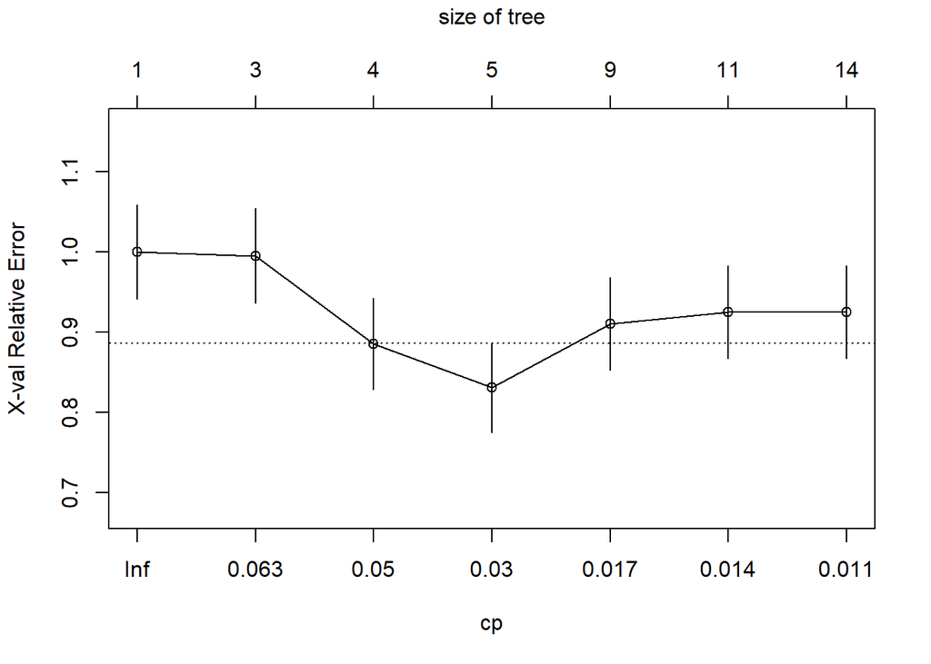

```r
set.seed(235)
library(ROCR)
res.tree <- rpart(Creditability~., data = ech)# ajustement de l'arbre non élagué
# elagage
plotcp(res.tree) # on peut voir que l'erreur de validation croisée (normalisée ici) est minimale pour un paramètre de complexité de 0.03
```

```r
res.prune <- prune(res.tree, cp = 0.03)
res.pred <- predict(res.prune, newdata = test)[,"good"]#calcul des probabilités d'être bon payeur sur l'échantillon test
AUC_CART <- performance(prediction(res.pred,test$Creditability), measure="auc")@y.values[[1]]#calcul de l'AUC
Err_CART <- performance(prediction(res.pred,test$Creditability), measure ="err")@y.values[[1]][4]#calcul de l'erreur de mauvais classement
cat("AUC CART : ", AUC_CART); cat(" Erreur CART : ", Err_CART)#affichage
```

```
## AUC CART :  0.7318484
```

```
##  Erreur CART :  0.2612613
```

L’AUC obtenue vaut 0.732 tandis que le taux de mauvais classement vaut 0.261.

```r
set.seed(235)
library(ipred)
bag <- bagging(Creditability~.,
             data = ech,
             nbagg = 200,
             coob = TRUE,# pour calculer l'erreur OOB
             control = rpart.control(minbucket = 5)# pour paramétrer le nombre de feuilles
             )
```

L’agrégation selon les probabilités d’appartenance aux deux classes conduit à une AUC de 0.788 sur l’échantillon test, contre 0.789 en agrégeant les prédictions fournies par les $B$ arbres selon le vote majoritaire.

```r
# agregation des probabilités d'appartenance
pred.val1 <- predict(bag, newdata = test, type = "prob", aggregation = "average")
pred1 <- prediction(pred.val1[,"good"], test$Creditability)
AUC_proba <- performance(pred1,"auc")@y.values[[1]]

# agregation des valeurs prédites
pred.val2 <- predict(bag, newdata = test, type = "prob", aggregation = "majority")
pred2 <- prediction(pred.val2[,"good"], test$Creditability)
AUC_pred <- performance(pred2, "auc")@y.values[[1]]

cat("AUC selon probabilités : ", AUC_proba);cat("AUC selon prédictions : ", AUC_pred)
```

```
## AUC selon probabilités :  0.7877493
```

```
## AUC selon prédictions :  0.7888932
```

Les performances sont donc proches, ce qui est vrai en général quand le nombre d’échantillons bootstrap est au-delà de quelques centaines. En considérant un nombre d’échantillons plus faible, la différence aurait été plus grande (et en faveur de la moyenne des probabilités).

Enfin, on peut vérifier que l’erreur OOB est proche du taux de mauvais classement obtenu sur l’échantillon test.

```r
modpred <- predict(bag, newdata = test, type = "class", aggregation = "average")
cat("erreur test : ", mean(modpred!=test$Creditability))
```

```
## erreur test :  0.2312312
```

```r
cat("erreur OOB : ", bag$err)
```

```
## erreur OOB :  0.2503748
```

NB : le nombre d’échantillons bootstrap a ici été choisi a priori à titre illustratif. Il conviendra en pratique de régler ce paramètre. Ceci pourra être effectué en examinant l’évolution de l’erreur OOB en fonction du nombre d’échantillons considérés, mais on utilisera en général plutôt une procédure de validation croisée. Ces deux stratégies peuvent être mises en oeuvre à l’aide du code R ci-dessous.

```r
########################
# Evolution de OOB en fonction du nombre d'échantillons
########################

gridB <- c(10, 20, 30, 50, 100, 200) # grille pour le nombre d'échantillons
OOB <- rep(NA, length(gridB))
names(OOB) <- as.character(gridB)

for(nbagg in gridB){
  set.seed(235)
  OOB[as.character(nbagg)] <- bagging(Creditability~.,
                                      data = ech,
                                      nbagg = nbagg,
                                      coob = TRUE,
                                      control = rpart.control(minbucket = 5))$err
}

plot(gridB, OOB)

###############################
# Validation croisée k-fold
###############################
K <- 10
foldsize <- floor(nrow(ech)/K)
fold <- matrix(sample(seq(nrow(ech)), size = foldsize*K),
               ncol = K,
               nrow = foldsize)

onefold_oneB <- function(nbagg, k, ech, fold){
  # applique le bagging pour une valeur de nbagg donnée pour un unique fold k
  # nbagg : nombre d'échantillons bootstrap
  # fold : matrice à K colonnes précisant les indices des individus de chaque fold
  # k : numero de la colonne de fold indiquant les individus servant pour le calcul de l'erreur
  # ech : données
    res.bag <- bagging(Creditability~.,
                       data = ech[-fold[,k],],
                       nbagg = nbagg,
                       control = rpart.control(minbucket = 5))
    #on détermine la valeurs de l'AUC à partir du fold test
    res.pred <- predict(res.bag, newdata = ech[fold[,k],], type = "prob", aggregation = "average")
    res.err <- performance(prediction(res.pred[,"good"],
                                      ech[fold[,k], "Creditability"]),
                           measure = "auc")
    res.out <- res.err@y.values[[1]]
    return(res.out)
  }

res.cv <- sapply(seq(K), FUN=function(k, fold, ech, grid){
  #validation croisée où le fold k sert en tant que test (et les autres pour l'apprentissage)

  # on applique la fonction précédente pour toutes les valeurs de B de la grille
  res.k <- sapply(grid, FUN = onefold_oneB, ech = ech, fold = fold, k = k)
  names(res.k) <- gridB
  return(res.k)
}, ech = ech, fold = fold, grid = gridB)

plot(gridB, 1-rowSums(res.cv), ylab = "1-AUC")
```

## 5.2 Forêts aléatoires

Les forêts aléatoires sont une procédure de bagging particulière dans le sens où non seulement les individus sont ré-échantillonnés (comme classiquement en bagging), mais où en plus les variables explicatives utilisées pour construire les noeuds sont choisies parmi un sous-ensemble de variables tiré au hasard de taille $L$. Ceci a pour effet de diminuer la liaison entre les différents arbres construits et améliore de ce fait les performances du prédicteur baggé. Le nombre de variables explicatives considéré $L$ diffère selon le cas de la régression ou de la classification. Dans le premier cas, on considère généralement $L=p/3$, tandis que dans le second, on retiendra généralement $L=\sqrt p$ (ce paramètre nécessite néanmoins d’être réglé). La prédiction par forêts aléatoires peut par exemple être effectuée à l’aide du package `randomForest`. Ici, avec 200 arbres on obtient une AUC de 0.793 sur l’échantillon de test.

```r
library(randomForest)
set.seed(235)
res.rf <- randomForest(y = ech$Creditability, x = ech[,-ncol(ech)],  ntree = 200)
val.pred <- predict(res.rf, newdata = test, type = "prob",aggregation = "average")[,1]
cat("AUC Random_Forest : ",
    performance(prediction(val.pred,test$Creditability),"auc")@y.values[[1]])
```

```
## AUC Random_Forest :  0.7925624
```

A nouveau, en pratique il convient de choisir le nombre d’arbres, tout comme le nombre de variables tirées à chaque noeuds. Comme précédemment, on peut procéder en considérant l’erreur OOB, ou via une procédure de validation croisée. Le package R `randomForest` contient notamment une fonction `tuneRF` permettant de choisir le nombre de variables via la première stratégie. Nous l’appliquons ici et montrons comment l’utiliser pour sélectionner conjointement ce nombre avec le nombre d’arbres.

```r
# choix du nombre de variables pour un nombre d'arbres fixé à 200

# valeur choisie par défaut
res.rf$mtry
```

```
## [1] 4
```

```r
# erreur OOB pour des valeurs de mtry (L) de plus en plus grande avec un pas de 2 (c'est-à-dire, en multipliant par 2 la valeur précédemment choisie ou en la divisant par 2)
res.tune.mtry <- tuneRF(y = ech$Creditability,
       x = ech[,-ncol(ech)],
       ntreeTry = 200,
       stepFactor = 2,
       improve = 0
       )
```

[figure not shown]

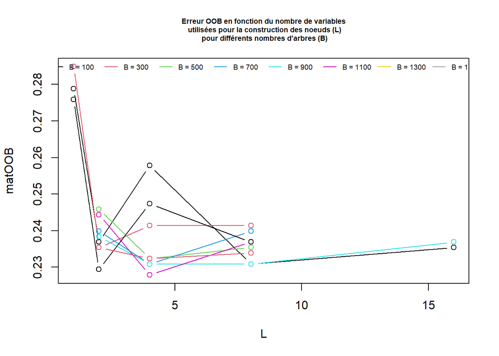

```r
# on recommence en considérant différents nombre d'arbres
gridB <- seq(100, 1500, 200)
res.tune.mtry.ntree <- lapply(gridB, FUN = function(B, x, y, stepFactor = 2){
  res <- tuneRF(y = y,
                x = x,
                ntreeTry = B,
                stepFactor = stepFactor,
                plot = FALSE,
                trace = FALSE,
                improve = 0
  )
  res.out <- res[,"OOBError"]
  names(res.out) <- res[,"mtry"]
  return(res.out)
},
y = ech$Creditability,
x = ech[,-ncol(ech)])

# mise en forme des résultats sous forme d'un tableau
names(res.tune.mtry.ntree)<-gridB
gridL <- unique(unlist(sapply(res.tune.mtry.ntree,names)))
gridL <- gridL[order(as.numeric(gridL))]
matOOB <-sapply(res.tune.mtry.ntree, FUN=function(res,gridL){
  res.out<-rep(NA, length(gridL))
  names(res.out)<-gridL
  res.out[names(res)]<-res
  return(res.out)
}, gridL = gridL, USE.NAMES = TRUE)

# affichage
col <- seq(1,length(gridB))
matplot(x = as.numeric(rownames(matOOB)),
        matOOB,
        lty = 1,
        type = "b",
        pch = 1,
        xlab = "L",
        main = "Erreur OOB en fonction du nombre de variables\n utilisées pour la construction des noeuds (L)\n pour différents nombres d'arbres (B)",
        cex.main = .6)
legend("top",horiz = TRUE, legend = paste("B =",gridB), col = col, lty=1, cex=.6, bty = "n")
```

Ici, l’erreur OOB est minimale pour $L=$ 4 variables et $B=$ 1100 arbres.

La seconde stratégie de sélection, par validation croisée, reste quant à elle similaire à celle proposée précédemment dans le cadre du bagging.

### 5.2.1 Importance des variables

Alors que les arbres sont des prédicteurs facilement interprétables, les forêts aléatoires ont davantage un aspect ``boîte noire’’. Calculer l’importance des variables dans ce contexte permettra de retrouver une interprétation de la forêt. L’importance des variables peut être calculée selon la *mean decrease accuracy*, comme expliqué plus haut, mais il existe un autre critère pour mesurer l’importance des variables dans ce contexte. Celui-ci est appelé *mean decrease impurety*. Il consiste à calculer la baisse d’impureté des noeuds résultant de la scission de la variable et de la moyenner sur l’ensemble des arbres.

Pour obtenir l’importance des variables dans le cadre des forêts aléatoires, on pourra utiliser par exemple la fonction `importance` du package `randomForest`.

```r
set.seed(235)
res.rf <- randomForest(y = ech$Creditability,x = ech[,-ncol(ech)], ntree = 1100, mtry = 4, importance = TRUE)
importance(res.rf, type = 2, scale = FALSE)# choisir type = 1 pour mean decrease accuracy ou type = 2 pour mean decrease impurety selon l'indice de Gini
```

```
##                              MeanDecreaseGini
## Status                             31.7867080
## Duration                           25.3718333
## History                            18.0937922
## Purpose                            24.8555269
## Credit.Amount                      32.5205002
## Savings.account.bonds              13.6949276
## Length.of.current.employment       16.7096371
## Instalment.per.cent                10.9906190
## Sex.Marital.Status                 10.0580218
## Guarantors                          5.7208015
## Duration.in.Current.address        11.0339614
## Property                           12.7600627
## Age.years                          24.2437897
## Other.installment.plans             8.9231435
## Housing                             7.3866039
## No.of.Credits.at.this.Bank          5.8769663
## Job                                 8.2575033
## No.of.dependents                    3.9670157
## Telephone                           4.7332187
## Foreign.Worker                      0.4529646
```

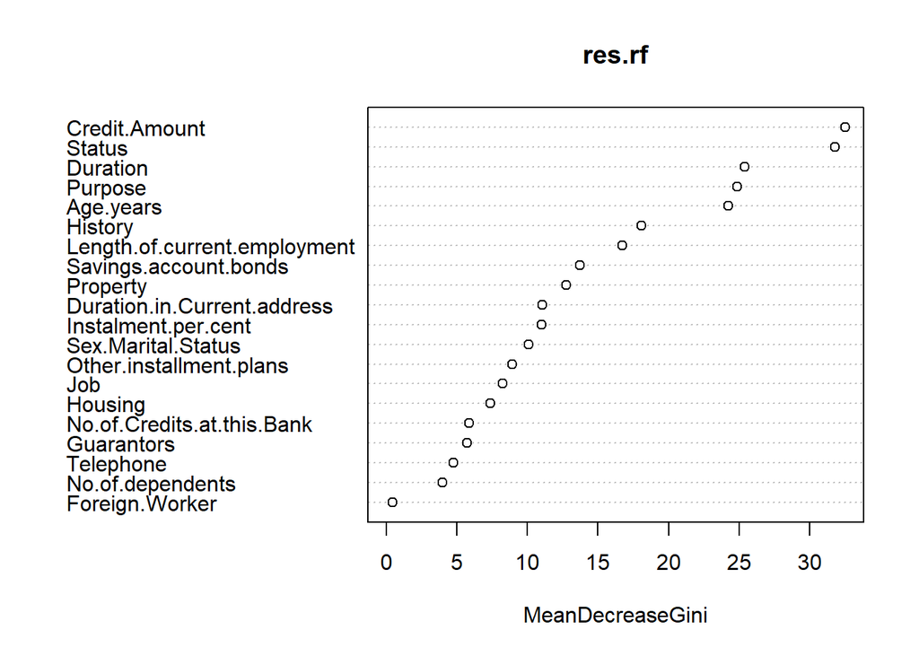

```r
varImpPlot(res.rf, type = 2, scale = FALSE)
```

### 5.2.2 Extra-Trees

Comme évoqué précédemment, le principe des forêts aléatoires par rapport au simple bagging est de renforcer l’indépendance entre les prédicteurs en tirant au hasard l’ensemble des variables candidates pour construire les noeuds. Les Extra-Trees (Extremely randomized Trees) poussent le principe un peu plus loin en construisant des noeuds selon des seuils aléatoires : plutôt que de déterminer le *meilleur seuil* de coupure pour chaque variable candidate (au sens de l’indice de Gini dans un cadre de classification par exemple) et de construire le noeud à partir de la meilleure variable à seuil fixé, les Extra-Trees consistent à considérer un *seuil tiré au hasard*, puis de retenir la meilleure variable pour un seuil aléatoire. Cette stratégie tend à augmenter le biais mais à diminuer la variance ce qui peut rendre le compromis plus intéressant que celui obtenu par les forêts. Le cas le plus extrême consiste à ne tirer qu’une unique variable à chaque noeud, rendant la construction des arbres complètement indépendants de la variable réponse et favorisant donc un peu plus l’indépendance entre les arbres. Un des intérêts des Extra-Trees par rapport aux forêts est leur coût algorithmique car il n’est plus nécessaire d’optimiser les seuils de coupure.

Afin de limiter le biais, l’algorithme des Extra-Trees n’effectue pas d’échantillonnage bootstrap. Par ailleurs, plusieurs seuils de scission aléatoire sont généralement considérés, permettant d’éviter des seuils très peu pertinents. Le package `extraTrees` implémente ce type d’algorithme. Le package a récemment été retiré du CRAN, mais reste accessible depuis un dépôt github, voici comment l’installer

```r
library(devtools)
install_github("hute37/extraTrees")
```

NB : le package `extraTrees` ne permet pas d’utiliser des variables explicatives de nature qualitatives. Pour y remédier, on peut procéder en utilisant les composantes d’une analyse factorielle (ACM ou AFDM en fonction de la nature des variables). Dans ce cas, la variable réponse doit être illustrative.

```r
# chargement des packages nécessaires
library(FactoMineR)
library(extraTrees)

# transformation des variables qualitatives en utilisant les composantes d'une AFDM

res.FAMD <- FAMD(don[c(id, setdiff(seq(nrow(don)), id)), ],# on ordonne les individus : les premiers sont les individus du jeu d'apprentissage, les autres ceux du jeu test
               ncp = Inf,
               graph = FALSE,
               ind.sup = seq(length(id)+1,nrow(don)),# les individus de l'échantillon test sont mis en illustratifs
                sup.var = ncol(don)
               )
ech.famd <- res.FAMD$ind$coord
test.famd <- res.FAMD$ind.sup$coord

res.extraT <- extraTrees(x = ech.famd,
           y = ech[,"Creditability"],
           ntree = 1000, # nombre d'arbres
           mtry = 1, # nombre de variables candidates à chaque noeuds
           numRandomCuts = 1,# nombre de scissions
           nodesize = 5,
           numThreads = 2# nombre de noeuds pour paralléliser les calculs
           )

res.pred <- predict(res.extraT, newdata = test.famd, probability = TRUE)[,"good"]
res.err <- performance(prediction(res.pred,test$Creditability), measure = "auc")@y.values[[1]]
res.err
```

```
## [1] 0.7340931
```

On observe une AUC de 0.734. A noter qu’il conviendrait de sélectionner le nombre d’arbres par validation-croisée (pas d’erreur OBB ici car seul un échantillon est considéré).

## 5.3 Boosting

A présent, on propose de comparer le bagging au boosting en utilisant comme prédicteur de base des stumps qui ont l’avantage d’être peu coûteux algorithmiquement. Le boosting peut être par exemple réalisé à l’aide du package R `ada` ou `gbm3`[[^1]](https://par.moodle.lecnam.net/pluginfile.php/1819944/mod_label/intro/bagging_boosting.html?time=1777897501168#fn1) (`gbm3` a l’avantage de pouvoir être utilisé dans le cas de la régression). On commence par inspecter l’influence du nombre d’itérations de la procédure sur l’erreur en considérant l’échantillon d’apprentissage ou l’échantillon test.

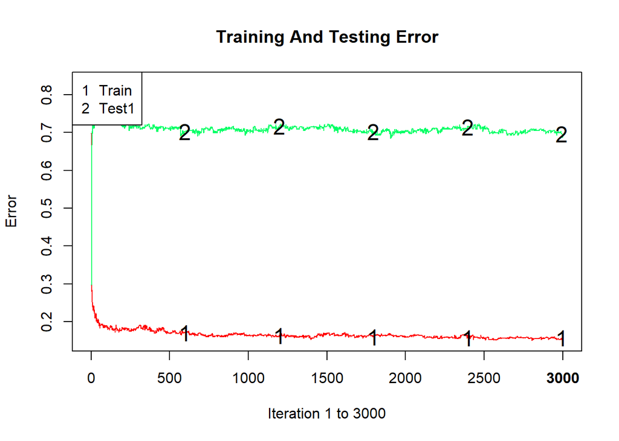

```r
library(ada)
set.seed(2356)
B <- 3000

model <- ada(Creditability~.,data = ech,
             iter = B,
             control = rpart.control(cp=-1, maxdepth=1),# paramètres pour stumps
             nu = 1,# constante multiplicative des poids
             test.x = test[,-ncol(test)],# variable réponse sur le jeu de données test
             test.y = test[,"Creditability"] # variables explicatives sur le jeu de données test
             )

plot(model, test = TRUE, tflag = TRUE)
```

Pour le package `gbm3`, on pourra procéder comme suit

```r
library(gbm3)
set.seed(235)
B <- 3000 #nombre d'itérations

# recodage de la variable Creditability sous format numerique, nécessaire pour utiliser la fonction gbm

ech$Creditability.num <- as.numeric(ech$Creditability)-1#0 = good
test$Creditability.num <- as.numeric(test$Creditability)-1
model <- gbm(Creditability.num~.,
             data = ech[,-21],
             distribution = "adaboost",
             interaction.depth = 1,
             shrinkage = 1,
             n.trees = B)

# représentation graphique de l'influence de B

grid.B<- seq(1, B, by = 30)
err.gbm <- sapply(grid.B,FUN=function(b, model, train, test){
   prev_app <- predict(model, newdata = train, n.trees = b)
   errapp <- sum(as.numeric(prev_app>0)!=train$Creditability.num)/nrow(ech)
   prev_test<- predict(model,newdata = test, n.trees = b)
   errtest <- sum(as.numeric(prev_test>0)!=test$Creditability.num)/nrow(test)
   res.out <- c("err_train" = errapp,"err_test" = errtest)
   return(res.out)
  },model = model,
 train = ech[,-which(colnames(ech)=="Creditability")],
 test = test[,-which(colnames(ech)=="Creditability")])
colnames(err.gbm) <- grid.B


plot(grid.B, err.gbm["err_train",], type = "b", col = "blue", ylim = c(0, 0.4), xlab = "nombre d'itérations", ylab = "erreur", lty = 1)
points(grid.B, err.gbm["err_test",], col = "red", type = "b", pch = 2)
abline(0.3, 0, lty = 2)
legend("bottomleft", legend = c("apprentissage","test"), col = c("blue","red"), pch = c(1,2), bty = "n")
```

[output not shown]

Il n’est pas évident de déterminer le nombre optimal d’itérations car le modèle est très rapidement sur-ajusté. Pour ralentir la convergence, on affecte un poids moins important aux individus mal-classés

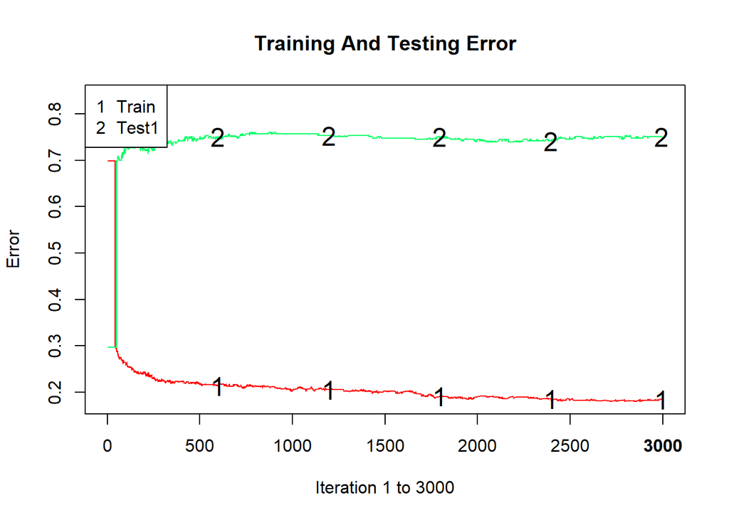

```r
set.seed(2356)

model <- ada(Creditability~.,data = ech,
             iter = B,
             control = rpart.control(cp = -1, maxdepth = 1),#paramètres pour stumps
             nu = 0.05,#constante multiplicative des poids
             test.x = test[, -ncol(test)],#variable réponse sur le jeu de données test
             test.y = test[, "Creditability"] #variables explicatives sur le jeu de données test
             )

plot(model, test = TRUE, tflag = TRUE)
```

En retenant les 1000 premiers arbres, on obtient une AUC à 0.786 sur l’échantillon test.

```r
val.pred <- predict(model, n.iter = 1000, type = "both", newdata = test[,-ncol(test)])

AUC_boosting <-  performance(prediction(val.pred$probs[,2], test$Creditability),"auc")@y.values[[1]]

cat("AUC boosting : ", AUC_boosting)
```

```
## AUC boosting :  0.7858931
```

Comparons à présent avec la procédure de bagging sur les stumps

```r
set.seed(235)
stump <- bagging(Creditability~., data = ech, nbagg = B,coob = TRUE, control = rpart.control(maxdepth = 1,cp=-1))
test$stump <- predict(stump,newdata = test, type = "prob", aggregation = "average")
pred <- prediction(test$stump[,1], test$Creditability)
AUC_bagging <- performance(pred, "auc")@y.values[[1]]
cat("AUC bagging : ", AUC_bagging)
```

```
## AUC bagging :  0.7356902
```

L’AUC est plus faible. Ceci n’est pas surprenant car le boosting permet de corriger à la fois le biais et la variance des stumps, tandis que le bagging ne diminue que la variance.

## 5.4 A propos de la parallélisation

En R les fonctions `lapply`, `sapply`, etc peuvent être facilement parallélisées à l’aide du package R `parallel`. Pour cela, il faut essentiellement remplacer ces fonctions par leur équivalent `parLapply`, `parSapply`, etc (voir aide du package). Nous fournissons ci-dessous un exemple minimal pour effectuer cette parallélisation. Celui-ci consiste à générer 3 jeux de données. Cet exemple pourra être repris pour d’autres tâches, notamment pour déterminer le nombre $B$ de prédicteurs utilisés en bagging.

```r
# Objectif : générer 3 jeux de données selon une loi normale

n <- 50# nb d'individus
Sigma <- diag(5)# matrice de variance-covariance
Nbsim <- 3# nb de tableaux

###########################
#version non parallélisée
###########################

res.nopar <- lapply(as.list(seq(Nbsim)),
       FUN = function(ii,n,Sigma){
                     res.out <- rmvnorm(n, sigma = Sigma)
                     return(res.out)
                   }
       , n = n, Sigma = Sigma)

# on effectue un résumé de chaque jeu généré
lapply(res.nopar, summary)

###########################
#version parallélisée
###########################

library(parallel)
nnodes <- detectCores(logical = FALSE)-1# nombre de noeuds pour la parallelisation, celui-ci dépend de votre ordinateur. La fonction detectCores permet de déterminer ce nombre. Choisir un nombre de noeuds un peu inférieur permet d'effectuer d'autre tâche sur l'ordinateur en même temps


cl <- makeCluster(nnodes, type = "PSOCK")# creation de nnodes consoles R en parallèle

clusterEvalQ(cl, library("mvtnorm"))#export d'un package, c'est comme ça qu'il faut procéder pour utiliser des packages pour les opérations parallélisées
clusterExport(cl,
              list("n", "Sigma"),
              envir = environment())#on exporte les objets dont on a besoin pour nos calculs parallélisés

# on parallelise sur les numéros des simulations. Pour cela il faut nécessaire d'utiliser des fonctions comme parLapply ou parSapply
res.par <- parLapply(cl,
                   as.list(seq(Nbsim)),
                   fun = function(ii, n, Sigma){
                     res.out <- rmvnorm(n, sigma = Sigma)
                     return(res.out)
                   }
                   , n = n, Sigma = Sigma)


stopCluster(cl)#on ferme les consoles

# res.par contient les 3 jeux de données
lapply(res.par, summary)
```

A noter, que le gain (en termes de temps) à effectuer de la parallélisation dépend essentiellement du temps nécessaire à effectuer la tâche qui est parallélisée. Si cette tâche demande très peu de temps de calcul, alors la parallélisation sera inutile, voire même contre-productive. A l’inverse, si cette tâche est coûteuse (disons qu’elle nécessite plusieurs secondes), alors la parallélisation aura un réel intérêt et permettra grosso modo de gagner un facteur temps égal à `nnodes`.

# 6 Conclusion

Les méta-algorithmes peuvent grandement améliorer les performances de prédiction d’un prédicteur de base. Ils sont souvent à la base des stratégies gagnantes des compétitions de sciences des données telles que le challenge Netflix. Néanmoins, il n’est pas garanti que le prédicteur agrégé soit plus performant que le prédicteur de base. Pour cette raison, il est important de s’assurer du gain à employer une procédure d’agrégation, sinon on risque juste de perdre en interprétabilité, voire de perdre également en qualité de prédiction.

Ce document se limite à l’agrégation d’arbres, mais il est possible d’agréger d’autres modèles. Le package `caret` propose notamment de nombreux estimateurs baggés (voir [ici](http://topepo.github.io/caret/train-models-by-tag.html#Bagging) pour la liste exhaustive). Le cadre de la combinaison de modèles est d’ailleurs plus large que l’agrégation de modèles appartenant à une même famille. Il est en effet possible de combiner des modèles issus de famille différentes, par exemple on pourrait combiner des prédictions par réseau neuronal et par régression logistique, on parle alors de *stacking*. Toute la difficulté est alors de définir le poids à accorder à chaque modèle. Dans un cadre de régression, on peut par exemple rechercher la combinaison linéaire des poids qui minimise le critère des moindres carrés entre les sorties observées et les sorties prédites (voir e.g. Hastie, Tibshirani, and Friedman (2009) pour plus de précisions). Pour aller plus loin sur le stacking on pourra consulter le [tutoriel de Ricco Rakotomalala](https://eric.univ-lyon2.fr/ricco/tanagra/fichiers/fr_Tanagra_Stacking_avec_R.pdf) présentant son utilisation sous R.

# Reférences

Duffy, Nigel, and David Helmbold. 2002. “Boosting Methods for Regression.” *Machine Learning* 47 (2): 153–200.

Hastie, Trevor, Robert Tibshirani, and Jerome Friedman. 2009. *The Elements of Statistical Learning*. Springer Series in Statistics. New York, NY, USA: Springer New York Inc. https://web.stanford.edu/~hastie/Papers/ESLII.pdf.

Tufféry, S. 2007. *Data Mining Et Statistique décisionnelle: L’intelligence Des Données*. Editions Technip.

———. 2015. *Modélisation Prédictive Et Apprentissage Statistique Avec r:* Éditions Technip.

Wikistat. 2017. “Agrégation de Modèles — Wikistat.” https://www.math.univ-toulouse.fr/~besse/Wikistat/pdf/st-m-app-agreg.pdf.

[^1]: le package `gbm` n’est plus maintenu sur le site du CRAN, les auteurs indiquent qu’il est préférable d’installer `gbm3` à partir du dépôt github, pour cela, il suffit d’exécuter la commande `r` devtools:::install_github(“gbm-developers/gbm3”)